# MchLrn-WgtLft-Fin

September 11, 2014

## Data Download and Library Set Up

```r
download.file("https://d396qusza40orc.cloudfront.net/predmachlearn/pml-training.csv", "../R-Data/pml-training.csv", method = "curl")
download.file("https://d396qusza40orc.cloudfront.net/predmachlearn/pml-testing.csv", "../R-Data/pml-testing.csv", method = "curl")
# Training Data
trn.dat <- read.csv("../R-Data/pml-training.csv", na.strings = c("NA", "", "#DIV/0!"))
# Test Data
tst.dat <- read.csv("../R-Data/pml-testing.csv", na.strings = c("NA", "", "#DIV/0!"))

library(caret)
library(ggplot2)
library(rattle)
library(rpart.plot)
library(ipred)
library(class)
library(randomForest)
```

## Data Exploration and Feature Extraction

We split the original training data set into 3 subsets:  
1. A true training data set used for data preprocessing and model training  
2. A validation data set used for assessing performance and selecting model  
3. An error prediction data set used for out-of-sample error prediction, for the model we end up selecting based on its performance on the validation set that we referred to in step 2 above.

We choose a 70:15:15 split for the 3 data sets, out of the original training set.

```r
#
# Start by splitting the training data into training and validation sets
#

set.seed(13931)
inTrain <- createDataPartition(y = trn.dat$classe, p = 0.7, list = FALSE)
trn <- trn.dat[inTrain, ]
val <- trn.dat[-inTrain, ]

#
# Now further split the validation data into validation and error prediction sets
#

set.seed(12421)
inVal <- createDataPartition(y = val$classe, p = 0.5, list = FALSE)
err <- val[-inVal,]
val <- val[inVal,]
```

We now perform some data exploration ahead of feature extraction. We do all this on the reduced training data set to avoid any data snooping.

```r
dim(trn)
dim(val)
dim(err)

str(trn)
```

[output not shown]

The data includes 159 predictors and a response variable (“classe”).  
We see many variables with large numbers of NA values, so we start by identifying these in order to remove them. We define a function to calculate the ratio of NA entries in a given vector, and we apply it to the columns of the training data set.

```r
na.ratio <- function(x) {
    n <- length(x)
    y <- is.na(x)
    return(sum(y)/n)
}

na.rates <- apply(trn, 2, na.ratio)
# na.rates
sum(na.rates > 0.95)
```

```
## [1] 100
```

We see that 100 of the predictors have NA in over 95% of their instances. We remove these predictors from the data set to make the analysis wieldy. It turns out that the rates of NA are either 97%-98% or else near zero.

```r
trn.use <- trn[, which(na.rates < 0.95)]
val.use <- val[, which(na.rates < 0.95)]
err.use <- err[, which(na.rates < 0.95)]
tst.use <- tst.dat[, which(na.rates < 0.95)]

dim(trn.use); dim(val.use); dim(err.use)
```

```
## [1] 13737    60
```

```
## [1] 2943   60
```

```
## [1] 2942   60
```

```r
dim(tst.use)
```

```
## [1] 20 60
```

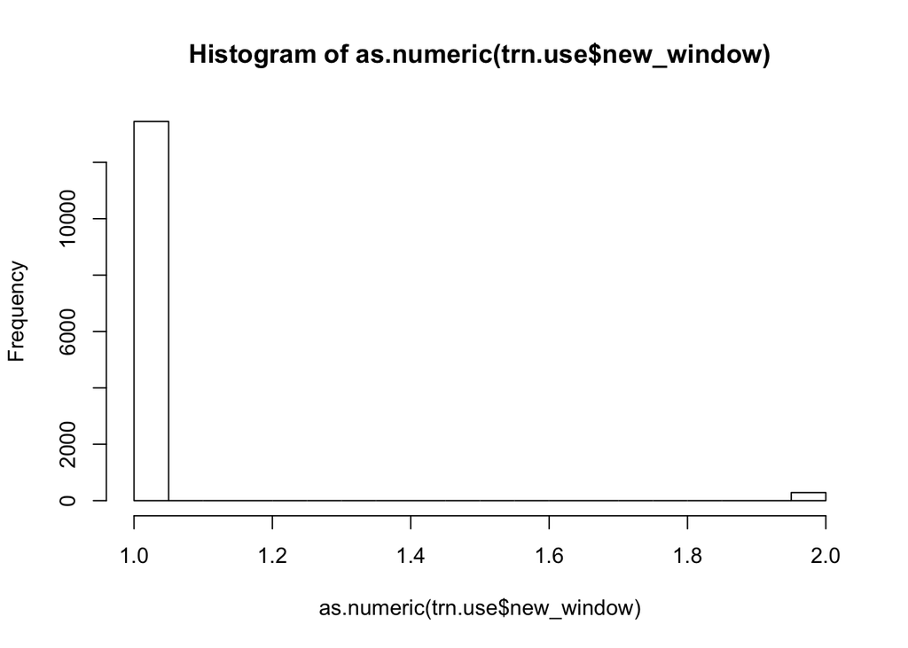

```r
hist(as.numeric(trn.use$new_window))
```

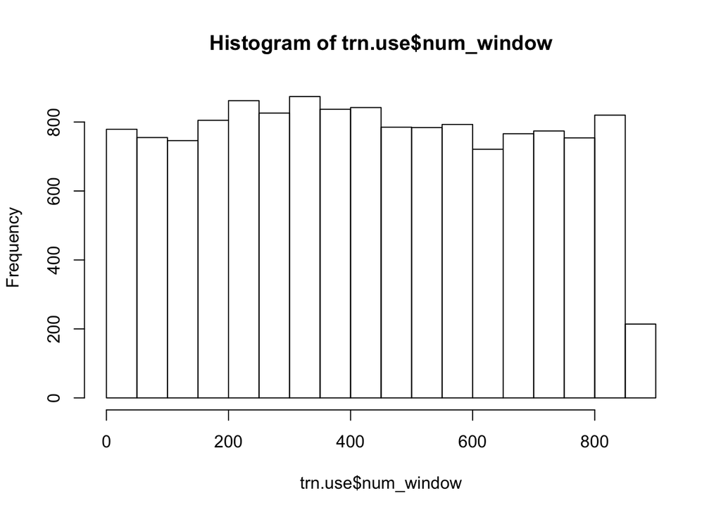

```r
hist(trn.use$num_window)
```

We also notice that the first predictors are names or identifiers or timestamps. We remove these as well, given their very low likelihood of any predictive value. These correspond to the first 7 predictors (and columns) in the data frames.

```r
trn.use <- trn.use[, -(1:7)]
val.use <- val.use[, -(1:7)]
err.use <- err.use[, -(1:7)]
tst.use <- tst.use[, -(1:7)]
dim(trn.use); dim(val.use); dim(err.use); dim(tst.use)
```

```
## [1] 13737    53
```

```
## [1] 2943   53
```

```
## [1] 2942   53
```

```
## [1] 20 53
```

Finally, we check for any further opportunities for reducing predictors without loss of predictive value. We do this by checking for low variance predictors.

```r
nzv <- nearZeroVar(trn.use, saveMetrics = TRUE)
sum((nzv$nzv == TRUE))
```

```
## [1] 0
```

All remaining predictors exhibit non-zero variability so there are no grounds for excluding any further variables from the models based on this criterion. If we intended to use linear methods and make inferences on model parameters, where collinearity among covariates is an issue, we would check the correlation matrix and possibly perform PCA to achieve both dimensionality reduction and transformation of features towards orthogonal ones.

However, we intend to use classification schemes based on trees and variations on trees (random forests and stochastic gradient boosting), so we skip the steps above.

We are done with feature preprocessing, if all we want to train are models that do not require specific distributions on the data. If we considered models such as LDA (Linear Discriminant Analysis) or QDA (Quadratic Discriminant Analysis), then we’d want to examine the validity of Gaussian assumptions, on the one hand, and the validity of uniformity of covariance assumptions (for LDA), and possibly explore feature transformations (log or otherwise) in case of skews or other salient signs of non-Gaussian shape in the data.

```r
#install.packages("parallel")
library(parallel)
#install.packages("bigmemory")
#library(bigmemory)
```